# Aplicacion de vacunas COVID19 en Argentina - NOMIVAC: 2020-2023

Lautaro Felipe Skubaletzky

2023-06-21

# 1 Carga de datos

```r
mi_muestra_registros <- 10000
mi_sample_registros  <- 7000

#source("scripts/carga_datos.R")

## Importar datos
source("scripts/importar_data.R")
```

```
## [1] "Reporte, importar_data.R: esta muestra carga con 10,000 observaciones."
```

```r
## Revision de filas repetidas
source("scripts/filtrar_data_repetida.R")
```

```
## [1] "Reporte, filtrar_data_repetida.R: esta muestra tiene 9,986 registros únicos."
```

```r
## Adecuación de valores (edición, agrupación y homogeneización)
source("scripts/arreglar_variables.R", local = TRUE, echo = FALSE)

## Agregacion de variables temporales.
source("scripts/agregar_variables_temporales.R")

## Seleccion del sample "cohorte - individuos"
source("scripts/samplear_data.R")
```

```
## [1] "Reporte, samplear_data.R: esta muestra aleatoria samplea 7,000 registros."
```

```r
## Obtener cohorte con ultima fecha_aplicacion
source("scripts/obtener_registros.R")
```

```
## [1] "Reporte, obtener_registros.R: esta muestra aleatoria samplea 5936 individuos."
```

```r
x_range_mes <- seq(1:12)
x_range_mes_lab <- c("ene", "feb", "mar", "abr", "may", "jun", "jul", "ago", "sept", "oct", "nov", "dic")

### PRUEBAS DE SANEAMIENTO
#verificar no duplicados entre id_per y ORDEN_
#data_reg %>% group_by(id_persona, orden_dosis) %>% summarise(n = n()) %>% arrange(desc(n))
#verificar no duplicados entre id_per y FECHA_
#data_reg %>% group_by(id_persona, fecha_aplicacion) %>% summarise(n = n()) %>% arrange(desc(n))
```

# 2 Generacion de tablas (for) y funciones

```r
## Set de varlists en Values
source("scripts/varlists_values.R")

## Generación de objetos del environment

### ls_ed_df (son ultima foto)
source("scripts/ls_estadesc1.R")
source("scripts/ls_estadesc2.R")

### ls_tv_sumdosis (variables del registro - no es ultima foto)
source("scripts/df_aplicaciones_diarias.R")
source("scripts/ls_tv_sumdosis.R")

## este puede generalizarse no solo para sexo y mejorar que las barras con fill sean apiladas
source("scripts/ls_prop_sexo_dosis.R")

## Cruce de variables

### producto: gh_pira_pobla
#source("scripts/df_piramide_poblacional.R") ## buen ejercicio.

### producto: k_jurisdicciones_poblacion
#source("scripts/df_jurisdicciones_poblacion.R")

### ls_gvar_gvar es cruce de variables
#source("scripts/ls_gvar_gvar.R") # puede mantenerse algo asi o la funcion

## Funciones

### Estadísticos de tabla general
source("functions/tabla_general.R")

### Gráfico estándar
source("functions/grafico_estandar.R")

### Cruzar variables
source("functions/cruzar_vars.R")

#tabla_general(ls_ed_df, "sexo")
#grafico_estandar(ls_ed_df, "sexo", "mean_dosis")
#cruzar_vars("data_per", "sexo", "grupo_etario")
```

# 3 Hipótesis

```r
ls_k <- list()
#ls: lista
#k: resultados
#h1: hipotesis 1
#df: dataframe
#dfk: dataframe::knitr
#gh: gráfico
#reg/per: scope de la base (reg-istros / per-sonas)
```

Aquí se presentan las hipótesis más jugosas que apuntan a la relación entre varias variables y a un fenómeno subyacente que puede tener implicancia y aplicaciones.

En esta sección se detallan las hipótesis programadas para guiar la exploración mas profunda del trabajo.

## 3.1 Priorización según condición de vulnerabilidad

Direccionamiento de las primeras dosis: La escasa disponibilidad de vacunas al comienzo de la pandemia forzó a las autoridades de salud pública a ordenar, priorizar y restringir la entrega de vacunas, dirigiendo las primeras etapas y rondas a las personas mas susceptibles, expuestas, vulnerables o de alto riesgo.

Para maximizar el cuidado general de la población se espraría que mayores de edad, personas con comorbilidades y personal estrategico fueron priorizados por el sistema, teniendo en cuenta que el criterio de priorización es evitar la muerte, seguido de evitar enfermar con gravedad y tener complicaciones.

Por esta razón se indagará en las etapas tempranas de vacunacion la incidencia de la poblacion objetivo sobre el total y comparar esos valores con los registrados al finalizar la emergencia mundial cuando la vacuna alcanzo la suficiencia en disponibilidad irrestricta. Para este apartado se dividirá el periodo analizado en 3 segmentos:

Tendencias de vacunación, intervalo temporal de los períodos seleccionados (subgrupos) * Periodo marcado por la escasez de vacunas (2021) * Periodo de abundancia de vacunas (2022 a junio 2022) * Periodo del declive de la demanda de vacunas (julio 2022 al presente)

**Corren 2 scripts:**

- Haciendo uso de `fecha_aplicacion`: agrega var periodo {son 3 etapas}
- Haciendo uso de `CONDICION_APLICACION` et `GRUPO_ETARIO`: agrega var cond_grupo {son 3 criterios}

```r
## Haciendo uso de `fecha_aplicacion`: agrega var periodo {son 3 etapas}
source("scripts/agregar_var_periodo.R")

## Haciendo uso de `CONDICION_APLICACION` et `GRUPO_ETARIO`: agrega var cond_grupo {son 3 criterios}
source("scripts/agregar_var_cond_grupo.R")
```

```
## [1] "Reporte agrupacion por condicion_aplicacion: 8 categorías -> 3 de cond_grupo"
## [1] "Reporte agrupacion por grupo_etario: 12 categorías -> 3 de cond_grupo"
```

```r
# H1: dataframe de registros
ls_k[["h1_df_reg"]] <- data_reg %>%
  filter(cond_grupo != "Estratégico") %>%
  group_by(periodo, cond_grupo) %>%
  summarise(n = n()) %>%
  mutate(prop = n / sum(n) * 100) %>%
  arrange(cond_grupo, periodo)

ls_k[["h1_dfk_reg"]] <- ls_k[["h1_df_reg"]] %>% knitr::kable(caption = "Participación de la población vacunada en cada período según vulnerabilidad", col.names = c("Período", "Condición", "Vacunaciones", "Proporción (período)"))

## Guardar grafico tendencia de la participacion en los periodos segun vulnerabilidad
ls_k[["h1_gh_reg"]] <- ls_k[["h1_df_reg"]] %>%
  ggplot(aes(periodo, prop, fill = cond_grupo)) +
  geom_col(position = position_dodge(width = 0.95)) +
  geom_text(aes(label = round(prop, 1)), vjust = -0.3, position = position_dodge(width = 0.9)) +
  theme_classic() +
  theme(axis.text.x = element_text(angle = 0, hjust = 0.5), legend.position = "right") +
  labs(title = "Participación de la población vacunada en cada período",
       subtitle = "Grupo según condición de vulnerabilidad",
       x = "Período",
       y = "Proporción",
       fill = "Condición")

# df identico salvo: data_reg -> data_per, es sin ponderacion.
ls_k[["h1_df_per"]] <- data_reg %>%
  group_by(id_persona) %>%
  filter(fecha_aplicacion == max(fecha_aplicacion)) %>%
  filter(cond_grupo != "Estratégico") %>%
  group_by(periodo, cond_grupo) %>%
  summarise(n = n()) %>%
  mutate(prop = n / sum(n) * 100) %>%
  arrange(cond_grupo, periodo)

# unir ambos df. reg y per.
# muestra composicion de la poblacion y distribucion de vacunas en ella.
ls_k[["h1_df_reg_per"]] <- ls_k[["h1_df_reg"]] %>%
  left_join(ls_k[["h1_df_per"]], join_by(periodo, cond_grupo), suffix = c(x="_reg", y="_per")) %>%
  select(periodo, cond_grupo, prop_reg, prop_per)

ls_k[["h1_dfk_reg_per"]] <- ls_k[["h1_df_reg_per"]] %>% knitr::kable(caption = "Participación de la población vacunada en cada período según vulnerabilidad", col.names = c("Período", "Condición", "Proporción (período, reg)", "Proporción (período, per)"))

## espacio_1

###ls_k[["h1_df_reg"]]
###ls_k[["h1_dfk_reg"]]
###ls_k[["h1_df_per"]]
###ls_k[["h1_df_reg_per"]]
# con los descomentados anteriores escribir la conclusion.

ls_k[["h1_df_per_prop"]] <- data_reg %>%
  group_by(id_persona) %>%
  filter(fecha_aplicacion == max(fecha_aplicacion)) %>%
  filter(cond_grupo != "Estratégico") %>%
  group_by(cond_grupo) %>%
  summarise(n = n()) %>%
  mutate(prop = n / sum(n) * 100)

ls_k[["h1_df_per_ordendosis"]] <- data_reg %>%
  group_by(id_persona) %>%
  filter(fecha_aplicacion == max(fecha_aplicacion)) %>%
  filter(cond_grupo != "Estratégico") %>%
  group_by(orden_dosis, cond_grupo) %>%
  summarise(n = n()) %>%
  mutate(prop = n / sum(n) * 100) %>%
  ggplot(aes(orden_dosis, prop, fill = cond_grupo)) +
  geom_col() +
  theme_classic() +
  theme(axis.text.x = element_text(angle = 0, hjust = 0), legend.position = "right") +
  labs(title = "Participación de la población vacunada por nivel de inmunización",
       subtitle = "Grupo según condición de vulnerabilidad",
       x = "Dosis acumuladas",
       y = "Proporción",
       fill = "Condición")

ls_k[["h1_dfk_per_prop"]] <- ls_k[["h1_df_per_prop"]] %>% knitr::kable(caption = "Participación de la población según vulnerabilidad", col.names = c("Condición", "Población", "Participación"))
```

Se presenta en este apartado el resultado de manipular las variables de `grupo_etario` y `condicion_aplicacion` con la finalidad de agrupar los conjuntos entre “No vulnerable” y “Vulnerable”.

Se dejó fuera del análisis el grupo correspondiente a personal “Estratégico”, por la positiva, se analizan los grupos que pueden afectarse mas precisamente a la condición de vulnerabilidad.

Se contrastan las proporciones que ocupan las vacunaciones destinadas a ambos grupos en cada uno de los períodos definidos anteriormente y se concluye que en contra de lo anunciado y lo previsto el grupo “No vulnerable” recibió más vacunaciones que el grupo “Vulnerable” en todos los períodos. La evolución a lo largo de los periodos fue progresiva en el sentido que los “Vulnerables” cobraron mayor peso en t=2 y t=3.

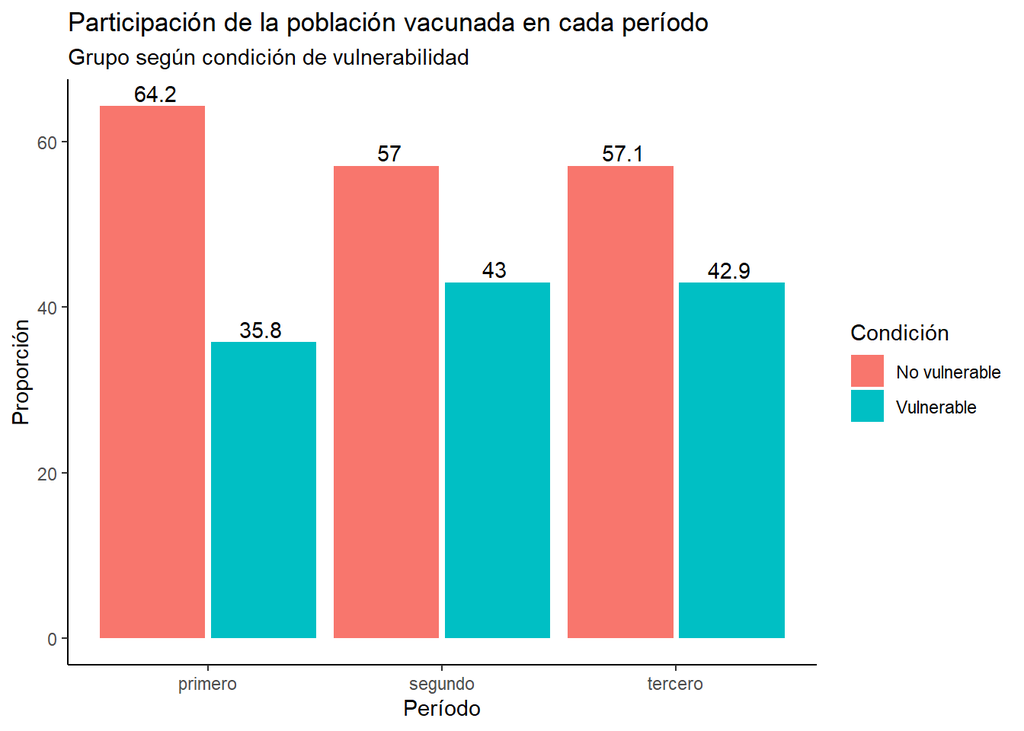

```r
ls_k[["h1_gh_reg"]]
```

Hay que tener en cuenta que existen mas personas “No vulnerables” que “Vulnerables” (59.3, 40.7) y se observa que la tendencia general del gráfico apunta con el correr de los períodos que cada grupo obtiene la cantidad de vacunaciones que le corresponde por su peso proporcional en la población.

```r
ls_k[["h1_dfk_per_prop"]]
```

Participación de la población según vulnerabilidad

| Condición | Población | Participación |
| --- | --- | --- |
| No vulnerable | 3346 | 59.2842 |
| Vulnerable | 2298 | 40.7158 |

Por último, se puede comparar el peso de la población vacunada de cada grupo por período contra la misma población no ponderada, es decir, considerando los individuos y no la vacunación de los mismos. A través de esta línea de análisis se puede interpretar los resultados anteriores en el marco de la participación de cada grupo en el total de individuos y total de vacunaciones.

*la tabla se interpreta: reg es registro y per es persona, registros de vacunas y personas es la parte poblacional, para cada período.*

```r
ls_k[["h1_dfk_reg_per"]]
```

Participación de la población vacunada en cada período según vulnerabilidad

| Período | Condición | Proporción (período, reg) | Proporción (período, per) |
| --- | --- | --- | --- |
| primero | No vulnerable | 64.24870 | 68.14516 |
| segundo | No vulnerable | 57.04588 | 59.38659 |
| tercero | No vulnerable | 57.06215 | 57.35403 |
| primero | Vulnerable | 35.75130 | 31.85484 |
| segundo | Vulnerable | 42.95412 | 40.61341 |
| tercero | Vulnerable | 42.93785 | 42.64597 |

```r
esta_tabla1 <- ls_k[["h1_df_reg_per"]] %>%
  mutate(signo = prop_reg - prop_per) %>%
  filter(periodo == "primero") %>%
  filter(signo == max(signo))
esta_tabla2 <- ls_k[["h1_df_reg_per"]] %>%
  mutate(signo = prop_reg - prop_per) %>%
  filter(periodo == "segundo") %>%
  filter(signo == max(signo))
esta_tabla3 <- ls_k[["h1_df_reg_per"]] %>%
  mutate(signo = prop_reg - prop_per) %>%
  filter(periodo == "tercero") %>%
  filter(signo == max(signo))
```

Los resultados deben entenderse desde el punto de vista de la proporción que ocupa cada grupo dentro de la población. Por ello, se expresan en términos relativos según la participación del grupo en el total comparado con la participación de los registros en el total.

- Durante el periodo primero: la población Vulnerable recibió 3.9% mas dosis que el otro grupo.
- Durante el periodo segundo: la población Vulnerable recibió 2.3% mas dosis que el otro grupo.
- Durante el periodo tercero: la población Vulnerable recibió 0.3% mas dosis que el otro grupo.

```r
rm(esta_tabla, esta_tabla1, esta_tabla2, esta_tabla3, este_resultado)
```

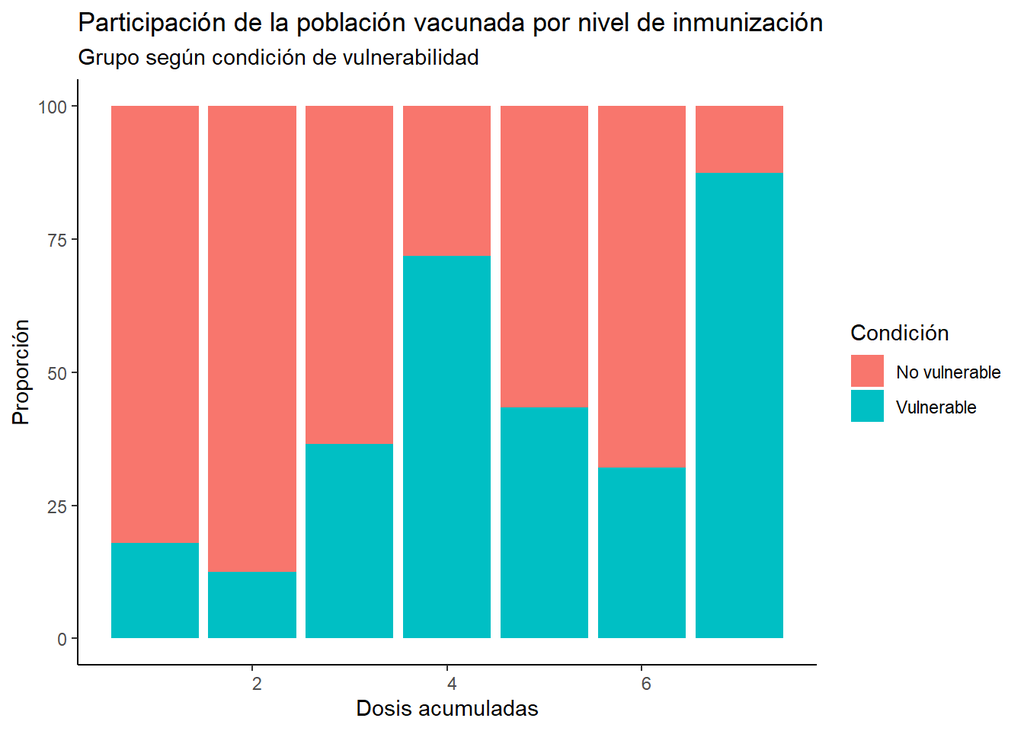

```r
ls_k[["h1_df_per_ordendosis"]]
```

## 3.2 Migraciones de lugar de residencia a aplicación

Migración de sujetos entre su residencia y su lugar de aplicación. Se realiza el análisis estático del mismo, solo último registro por persona. El análisis adquiere más sentido si se elimina el factor de multiplicación de la cantidad de registros.

Por jurisdicción: * personas residentes-de-jur, * personas residentes-de-jur-aplicadas-en-jur, * personas residentes-de-jur-aplicadas-en-otra-jur, * personas aplicadas-en-jur, * personas no-residentes-de-jur-aplicadas-en-jur * personas no-residentes-de-jur-aplicadas-en-jur (+/-),

Posiblemente existió una migración de poblaciones debido al ASPO que puede observarse mediante este cruce o simplemente pueda obtenerse una “foto” de como las personas se mueven de su residencia hasta la aplicación. Se creará a este efecto un cruce de jurisdicciones y un relevamiento de que jurisdicciones se hicieron cargo de su población residente y cuales colaboraron con la vacunación de no residentes.

**Se corre un script** Crear tabla jurisdicciones origen - destino.

```r
source("scripts/df_jurisdicciones_poblacion.R")
```

```
## [1] "Producto de df_jurisdicciones_poblacion: ls_k[[df_jur_pobla]] y ls_k[[dfk_jur_pobla]]"
```

```r
#ls_k[["df_jur_pobla"]]
ls_k[["dfk_jur_pobla"]]
```

| Jurisdiccion | Residentes | Residentes vacunados in situ | Residentes vacunados out situ | Poblacion vacunada in situ | No residentes vacunados in situ | Saldo de vacunados neto |
| --- | --- | --- | --- | --- | --- | --- |
| Buenos Aires | 1927 | 1870 | 57 | 1939 | 69 | 12 |
| CABA | 297 | 265 | 32 | 326 | 61 | 29 |
| Catamarca | 56 | 52 | 4 | 55 | 3 | -1 |
| Chaco | 441 | 432 | 9 | 438 | 6 | -3 |
| Chubut | 56 | 52 | 4 | 55 | 3 | -1 |
| Corrientes | 349 | 341 | 8 | 344 | 3 | -5 |
| Córdoba | 538 | 515 | 23 | 526 | 11 | -12 |
| Entre Ríos | 454 | 441 | 13 | 454 | 13 | 0 |
| Formosa | 197 | 195 | 2 | 200 | 5 | 3 |
| Jujuy | 50 | 48 | 2 | 52 | 4 | 2 |
| La Pampa | 25 | 25 | 0 | 27 | 2 | 2 |
| La Rioja | 24 | 23 | 1 | 24 | 1 | 0 |
| Mendoza | 215 | 208 | 7 | 212 | 4 | -3 |
| Misiones | 209 | 201 | 8 | 204 | 3 | -5 |
| Neuquén | 110 | 101 | 9 | 113 | 12 | 3 |
| Río Negro | 243 | 225 | 18 | 234 | 9 | -9 |
| Salta | 130 | 130 | 0 | 133 | 3 | 3 |
| San Juan | 58 | 52 | 6 | 55 | 3 | -3 |
| San Luis | 128 | 127 | 1 | 133 | 6 | 5 |
| Santa Cruz | 46 | 41 | 5 | 43 | 2 | -3 |
| Santa Fe | 1144 | 1116 | 28 | 1130 | 14 | -14 |
| Santiago del Estero | 84 | 81 | 3 | 89 | 8 | 5 |
| Tierra del Fuego | 79 | 72 | 7 | 73 | 1 | -6 |
| Tucumán | 140 | 137 | 3 | 141 | 4 | 1 |

```r
esta_tabla <- ls_k[["df_jur_pobla"]] %>%
  filter(vac_extra > 0) %>%
  select(jurisdiccion, vac_extra)

#source("scripts/df_jurisdicciones_poblacion2.R") VER! PENDIENTES
```

Las jurisdicciones que colaboraron con la campaña de vacunación obteniendo aplicaciones netas positivas entre aplicados y residentes, es decir, que en parte se hicieron cargo del operativo vacunatorio de personas no residentes son: Buenos Aires, CABA, Formosa, Jujuy, La Pampa, Neuquén, Salta, San Luis, Santiago del Estero, Tucumán

Se presenta en el siguiente gráfico las jurisdicciones según su saldo neto de vacunación de personas aplicadas deducida la cantidad de personas residentes. Se observa que algunas jurisdicciones han operado de receptoras de personas no residentes y atendieron su vacunación cuando en su jurisdicción de origen no le han provisto la dosis.

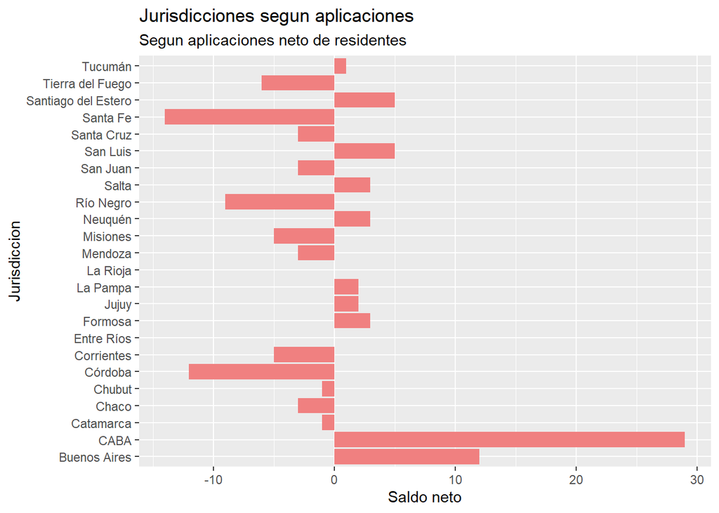

```r
ls_k[["df_jur_pobla"]] %>%
  select(jurisdiccion, vac_extra) %>%
  ggplot(aes(vac_extra, jurisdiccion)) +
  geom_col(fill = "lightcoral") +
  labs(title = "Jurisdicciones segun aplicaciones",
       subtitle = "Segun aplicaciones neto de residentes",
       x = "Saldo neto",
       y = "Jurisdiccion")
```

## 3.3 Aplicaciones diarias

Se comenzó a flexibilizar la ASPO (AISLAMIENTO SOCIAL PREVENTIVO Y OBLIGATORIO) desde la gran disponibilidad de vacunas a partir del 2022. Veremos cuando se registraron picos de vacunación que permitieron una mayor circulación libre e irrestricta para todos.

Se buscará encontrar patrones de visita al vacunatorio, si la vacunación tiende a ser mas frecuente un día de la semana particular, o no existe correlación.

### 3.3.1 Participación por año

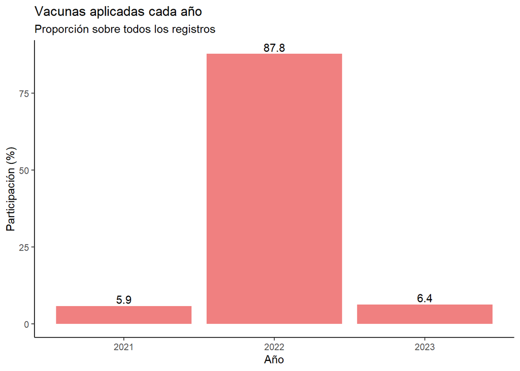

```r
ls_tv_sumdosis[["anio"]] %>%
  ggplot(aes(x = anio, y = part_dosis)) +
  geom_col(fill = "lightcoral") +
  geom_text(aes(label = round(part_dosis, 1)), vjust = -0.3) +
  theme(axis.text.x = element_text(angle = 0, hjust = 0)) +
  labs(title = "Vacunas aplicadas cada año",
       subtitle = "Proporción sobre todos los registros",
       x = "Año",
       y = "Participación (%)",
       fill = "") +
  theme_classic()
```

```r
este_resultado <- ls_tv_sumdosis[["anio"]] %>%
  filter(part_dosis == max(part_dosis))
```

Se presenta una enorme asimetría en la cantidad de aplicaciones por año. Donde 2022 se aplicaron 6144 dosis con un peso de 87.7714286% sobre el total.

### 3.3.2 Participación por mes (2022)

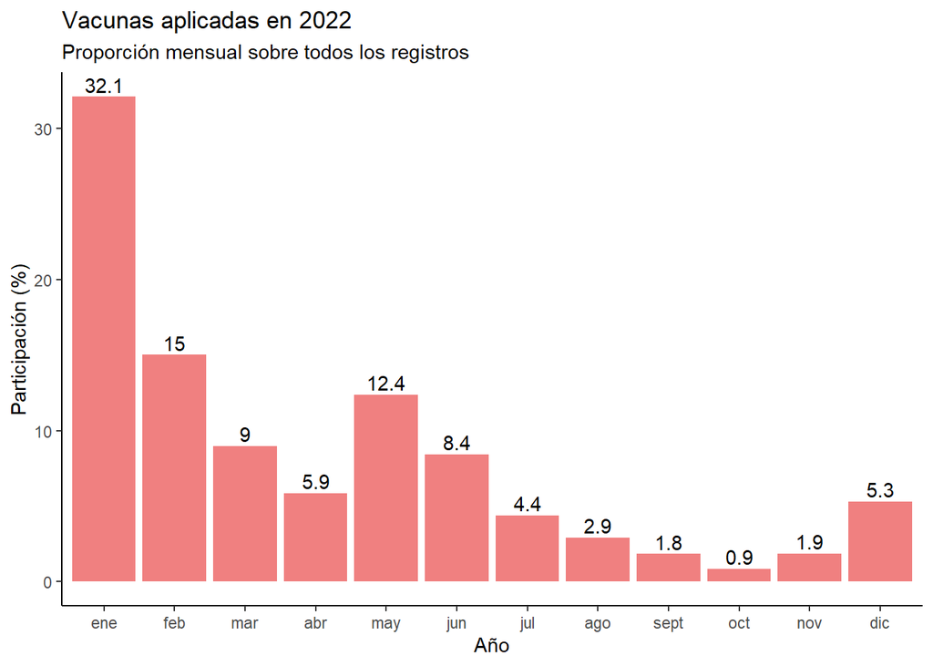

```r
#ls_tv_sumdosis[["aplicaciones_diarias_wide"]]

esta_tabla <- data_reg %>%
  filter(anio == 2022) %>%
  group_by(anio_mes) %>%
  summarise(n = n()) %>%
  mutate(part_dosis = n / sum(n) * 100)

esta_tabla %>%
  ggplot(aes(x = anio_mes, y = part_dosis)) +
  geom_col(fill = "lightcoral") +
  geom_text(aes(label = round(part_dosis, 1)), vjust = -0.3) +
  theme(axis.text.x = element_text(angle = 0, hjust = 0)) +
  labs(title = "Vacunas aplicadas en 2022",
       subtitle = "Proporción mensual sobre todos los registros",
       x = "Año",
       y = "Participación (%)",
       fill = "") +
  theme_classic() +
  scale_x_discrete(labels = x_range_mes_lab)
```

```r
este_resultado <- esta_tabla %>%
  filter(part_dosis == max(part_dosis))
```

Dentro del año con mas aplicaciones el mes de mayor aplicación tambien se encuentra muy concentrado. Donde 2022-01 es el mes en que se aplicó el máximo de 1972 dosis con un peso de 32.1% sobre el total.

### 3.3.3 Participación por día

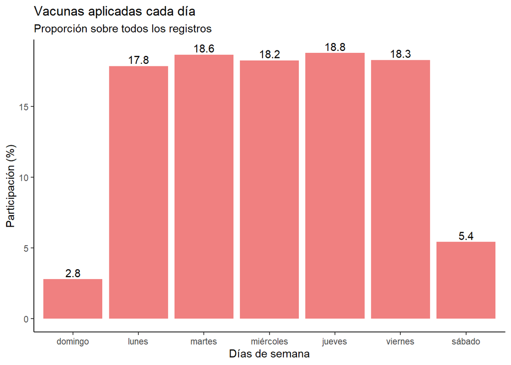

```r
ls_tv_sumdosis[["dia"]] %>%
  ggplot(aes(x = dia, y = part_dosis)) +
  geom_col(fill = "lightcoral") +
  geom_text(aes(label = round(part_dosis, 1)), vjust = -0.3) +
  theme(axis.text.x = element_text(angle = 0, hjust = 0)) +
  labs(title = "Vacunas aplicadas cada día",
       subtitle = "Proporción sobre todos los registros",
       x = "Días de semana",
       y = "Participación (%)",
       fill = "") +
  theme_classic()
```

```r
esta_tabla <- ls_tv_sumdosis[["dia"]] %>%
  filter(part_dosis >= mean(part_dosis))
otra_tabla <- ls_tv_sumdosis[["dia"]] %>%
  filter(part_dosis < mean(part_dosis))
```

En los días lunes, martes, miércoles, jueves, viernes se aplicó el 91.7714286% de las dosis con un promedio de 18.3542857% cada día, mientras que los días domingo, sábado se aplicó el 8.2285714% de las dosis con un promedio de 4.1142857% cada día.

### 3.3.4 Aplicaciones por fecha

A modo de yapita se presenta un gráfico con la cantidad de dosis aplicadas cada día desde el comienzo hasta el final de registros y para hacerla mas colorida se incluye el nombre de la vacuna como factor.

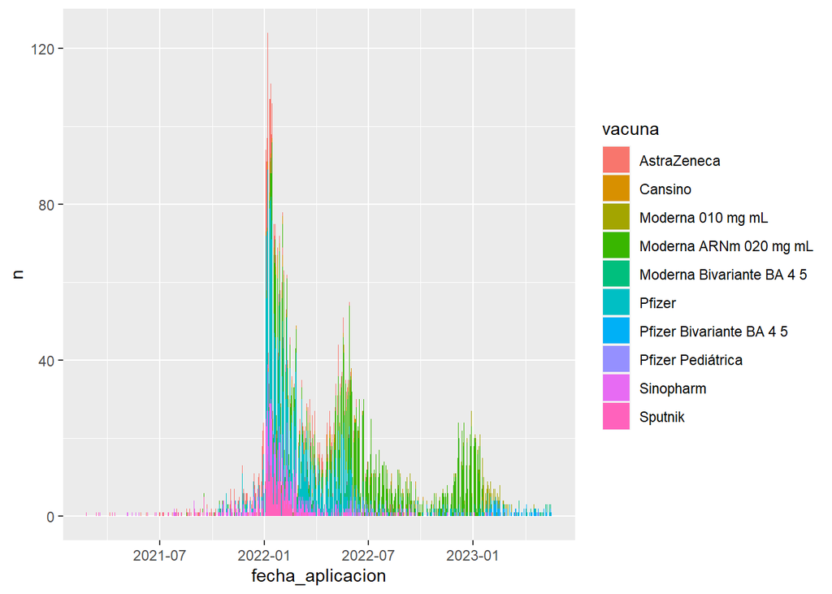

```r
data_reg %>%
  group_by(fecha_aplicacion, vacuna) %>%
  summarise(n = n()) %>%
  ggplot(aes(fecha_aplicacion, n, fill = vacuna)) +
  geom_col()
```

## 3.4 Caracterizar población, adherencia y nivel de inmunización.

Los mas jóvenes y la adherencia: sea por el motivo que fuere los jóvenes son menos adherentes a los mandatos y perciben de manera parcial los riesgos. Esa conducta y pensamiento puede llevarlos a no aceptar la aplicación de vacunas, desconfiar de ellas y saltarse los esquemas o plataformas iniciados, reduciendo la tasa de inmunización global de la población. Para cada grupo etario se obtendrá un porcentaje de personas cubiertas por una, dos, … más vacunas. Se considera a tales efectos el seguimiento de los jóvenes digamos con años entre 18 y 29 años.

### 3.4.1 Piramide poblacional

**Corre un script** Crear la piramide poblacional. Veamos cómo se construye nuestra piramide poblacional según `sexo` y `grupo_etario`. El grupo de jóvenes de 18 a 29 son los grupos más numerosos para ambos sexos.

```r
source("scripts/df_piramide_poblacional.R")
```

```
## [1] "Producto de df_piramide_poblacional: ls_k[[df_pira_pobla]] y ls_k[[gh_pira_pobla]]"
```

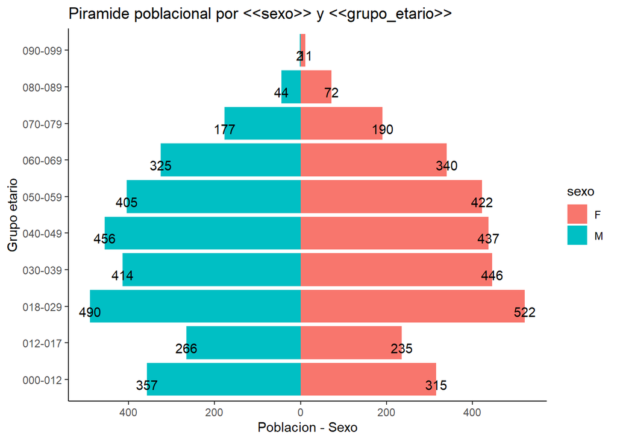

```r
#ls_k[["df_pira_pobla"]]
ls_k[["gh_pira_pobla"]]
```

### 3.4.2 Ciclo de vida: no vulnerables y adherencia

**Corre un script** Se agrega una variable a `data_reg` -> `ciclo_de_vida`.

```r
source("scripts/agregar_var_ciclo_de_vida.R")

print("Una vez creadas las variables de ciclo de vida, se quitan los registros de personas vulnerables que tienen condicionantes particulares sobre la vacunación o no aplicación. Luego se quitan los menores de edad que tampoco gozan de plena libertad sobre su derecho de decidir.")
```

```
## [1] "Una vez creadas las variables de ciclo de vida, se quitan los registros de personas vulnerables que tienen condicionantes particulares sobre la vacunación o no aplicación. Luego se quitan los menores de edad que tampoco gozan de plena libertad sobre su derecho de decidir."
```

```r
df_ciclo <- data_reg %>%
  subset(cond_grupo == "No vulnerable")

# registros en cada grupo obj.
df_ciclo_reg <- df_ciclo %>%
  group_by(ciclo_de_vida) %>%
  summarise(n = n())

# personas en cada grupo obj.
df_ciclo_per <- df_ciclo %>%
  group_by(id_persona) %>%
  filter(fecha_aplicacion == max(fecha_aplicacion)) %>%
  group_by(ciclo_de_vida) %>%
  summarise(n = n())

# Join de personas y registros
df_ciclo_join <- df_ciclo_per %>%
full_join(df_ciclo_reg, by = "ciclo_de_vida", suffix = c("_personas", "_registros"))

# calculo dosis promedio
df_ciclo_join <- df_ciclo_join %>%
  mutate(dosis_prom = n_registros / n_personas) %>% arrange(desc(dosis_prom))

df_ciclo_join %>%
  knitr::kable(caption = "Poblacion por ciclo de vida", col.names = c("Ciclo de vida", "Poblacion", "Aplicaciones", "Dosis promedio"))
```

Poblacion por ciclo de vida

| Ciclo de vida | Poblacion | Aplicaciones | Dosis promedio |
| --- | --- | --- | --- |
| adulto | 1599 | 1812 | 1.133208 |
| menor | 1029 | 1166 | 1.133139 |
| joven | 759 | 851 | 1.121212 |

```r
# mismo analisis para poblacion vulnerable
df_ciclo <- data_reg %>%
  subset(cond_grupo == "Vulnerable")

# registros en cada grupo obj.
df_ciclo_reg <- df_ciclo %>%
  group_by(ciclo_de_vida) %>%
  summarise(n = n())

# personas en cada grupo obj.
df_ciclo_per <- df_ciclo %>%
  group_by(id_persona) %>%
  filter(fecha_aplicacion == max(fecha_aplicacion)) %>%
  group_by(ciclo_de_vida) %>%
  summarise(n = n())

# join de personas y registros
df_ciclo_join <- df_ciclo_per %>%
full_join(df_ciclo_reg, by = "ciclo_de_vida", suffix = c("_personas", "_registros"))

# calculo dosis promedio
df_ciclo_join <- df_ciclo_join %>%
  mutate(dosis_prom = n_registros / n_personas)

#df_ciclo_join
```

.

```r
rm(df_ciclo, df_ciclo_per, df_ciclo_reg, df_ciclo_join)
```

### 3.4.3 Niveles de inmunizacion por sexo

**Corre un script** Mediante la cantidad de población acumulada segun niveles de inmunización se puede alcanzar conclusiones del tipo: el *xx%* del grupo *X* tiene **al menos** *x* dosis.

```r
source("scripts/ls_prop_sexo_dosis.R")

#este R me gustaría trabajarlo en function, para poder iterar entre diferentes variables, por ejemplo condicion_aplicacion y así obtener con el agregado de una fecha de corte las frecuencias acumuladas de inmunizacion por niveles de dosis para cada grupo en diferentes momentos y crear un grafico interactivo sobre ello.
#Solo preservaria el nivel alcanzado y frecuencia acumulada para aquellso que tienen varias agrupaciones.

#De la tabla, dificil de inteligir, se extrae qué porcentaje de cada grupo se encuentra mas inmunizado para cada nivel de inmunización.

#Cuanto más alto el nivel de `Freq_rel_acum_sexo` vs el `otro`, el mas alto tiene mayor proporción del grupo_sexo inmunizado a un menor nivel de cobertura.

ls_prop_sexo_dosis[["sexos_dosis"]] %>%
  knitr::kable(caption = "Nivel de inmunizacion por sexo", col.names = c("Nivel", "Masculinos", "Participacion masculinos", "Frecuencia acum. masc.", "Femeninos", "Participacion femeninos", "Frecuencia acum. feme."))
```

Nivel de inmunizacion por sexo

| Nivel | Masculinos | Participacion masculinos | Frecuencia acum. masc. | Femeninos | Participacion femeninos | Frecuencia acum. feme. |
| --- | --- | --- | --- | --- | --- | --- |
| 1 | 290 | 9.8773842 | 9.877384 | 248 | 8.2943144 | 8.294314 |
| 2 | 477 | 16.2465940 | 26.123978 | 434 | 14.5150502 | 22.809365 |
| 3 | 1375 | 46.8324251 | 72.956403 | 1446 | 48.3612040 | 71.170569 |
| 4 | 762 | 25.9536785 | 98.910082 | 828 | 27.6923077 | 98.862876 |
| 5 | 14 | 0.4768392 | 99.386921 | 16 | 0.5351171 | 99.397993 |
| 6 | 12 | 0.4087193 | 99.795640 | 16 | 0.5351171 | 99.933110 |
| 7 | 6 | 0.2043597 | 100.000000 | 2 | 0.0668896 | 100.000000 |

```r
esta_tabla <- ls_prop_sexo_dosis[["sexos_dosis"]] %>%
  select(orden_dosis, Freq_rel_acum_M, Freq_rel_acum_F) %>%
  pivot_longer(cols = starts_with("Freq_"),
               names_to = "sexo",
               values_to = "FreAcum")

esta_tabla <- esta_tabla %>%
  mutate(sexo = ifelse(sexo == "Freq_rel_acum_F", "femenino", sexo)) %>%
  mutate(sexo = ifelse(sexo == "Freq_rel_acum_M", "masculino", sexo)) %>%
  mutate(almenos = 100 - FreAcum)

este_grafico <- esta_tabla %>%
  ggplot(aes(x = orden_dosis, y = almenos, fill = sexo)) +
  geom_col(position = position_dodge(width = 0.95)) +
  geom_text(aes(label = round(almenos, 1)),
            vjust = -0.3,
            position = position_dodge(width = 0.9)) +
  theme_classic() +
  theme(axis.text.x = element_text(angle = 0, hjust = 0.5), legend.position = "right") +
  labs(title = "Poblacion por nivel de inmunizacion",
       subtitle = "Grupo segun sexo",
       x = "Nivel de inmunizacion",
       y = "Proporcion",
       fill = "Sexo")

este_grafico2 <- esta_tabla %>%
  ggplot(aes(x = orden_dosis, y = FreAcum, fill = sexo)) +
  geom_col(position = position_dodge(width = 0.95)) +
  geom_text(aes(label = round(FreAcum, 1)),
            vjust = -0.3,
            position = position_dodge(width = 0.9)) +
  theme_classic() +
  theme(axis.text.x = element_text(angle = 0, hjust = 0.5), legend.position = "right") +
  labs(title = "Poblacion por nivel de inmunizacion",
       subtitle = "Grupo segun sexo",
       x = "Nivel de inmunizacion",
       y = "Proporcion",
       fill = "Sexo")

masdif <- esta_tabla %>%
  group_by(orden_dosis) %>%
  mutate(diferencia = max(almenos) - min(almenos)) %>%
  select(orden_dosis, almenos, diferencia) %>%
  subset(diferencia == max(diferencia)) %>%
  select(orden_dosis) %>%
  group_by(orden_dosis) %>%
  summarise() %>%
  as.matrix
```

El gráfico debe interpretarse de la siguiente forma: para cada grupo y nivel de inmunización existe al menos *xx%* con más aplicaciónes. Se puede ver la mayor diferencia entre ambos sexos en el nivel 2 de inmunización.

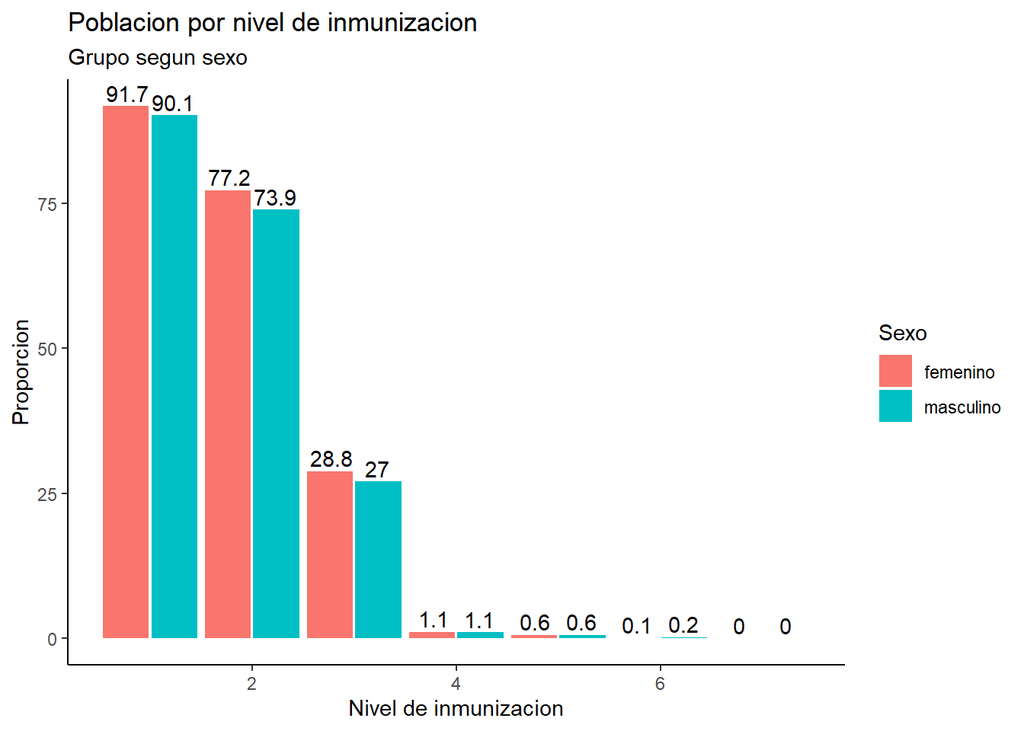

```r
este_grafico
```

```r
difmax <- esta_tabla %>%
  filter(orden_dosis == masdif[1]) %>%
  filter(FreAcum == max(FreAcum))
difmin <- esta_tabla %>%
  filter(orden_dosis == masdif[1]) %>%
  filter(FreAcum == min(FreAcum))

#difmax
#difmin
```

El sexo femenino se encuentra más protegido ya que el 77.2% tiene más que 2 dosis aplicadas mientras que los masculino tienen 73.9%.

.

```r
rm(difmax, difmin, masdif, esta_tabla, este_grafico, este_grafico2)
#source("functions/remover_temporales()")
```

## 3.5 Plataforma y vacunas

Cambios de plataforma * Por persona: que vacunas recibió.

Plataforma finalizada * Por persona: plataforma terminada y/o + refuerzo. (quienes abandonan plat.?) * Niveles de inmunización alcanzados. foto * Los jovenes y la adherencia de los esquemas. foto.

## 3.6 Direccionamiento por densidad demografica.

Las condiciones de vida en las grandes ciudad impide mantenerse aislado (transporte, abastecimiento, servicios) y aumenta la probabilidad de transmisión de virus. Los habitantes viven en condiciones de hacinamiento, inevitablemente poca distancia social, habitats sobrepoblados, transportes congestionados.

Priorizar habitantes de grandes ciudades por dificultad de mantener la distancia social debido a la restricción espacial y densidad demográfica puede ser medida adecuada y lógica de mitigar y desacelerar la transmisión de virus.

Se puede analizar por departamentos provinciales, en donde `depto_residencia` sean mas numerosos agrupados contra los menos numerosos. Ver porcentajes de vacunación de deptos respecto a su población de referencia.

## 3.7 Días de descanso entre dosis

Calcular para cada sujeto los dias de descanso transcurridos entre una dosis y la siguiente. Mediante la fecha de aplicacion de cada registro para cada persona. Se calculará la cantidad de dias que pasan entre una dosis y otra: dias_prom_vac1_vac2, dias_prom_vac2_vac3… y un total para dias_prom_vac1_vac10 promedio para cada grupo.

```r
df_descanso <- data_reg %>%
  group_by(id_persona, fecha_aplicacion) %>%
  summarise(n = n()) %>%
  arrange(desc(n))
# Paso 1: Dosis identificar orden.
df_descanso <- data_reg %>%
  group_by(id_persona) %>%
  arrange(id_persona, fecha_aplicacion) %>%
  select(id_persona, fecha_aplicacion) %>%
  mutate(dosis_number = row_number()) %>%
  arrange(desc(dosis_number))

# Paso 2: Convertir los datos de formato largo a ancho
df_descanso_wide <- df_descanso %>%
  pivot_wider(names_from = dosis_number, values_from = fecha_aplicacion, names_prefix = "dosis_")

# Paso 3: Calcular la diferencia en días entre dosis
df_descanso_wide <- df_descanso_wide %>%
  mutate(d12 = dosis_2 - dosis_1) %>%
  mutate(d23 = dosis_3 - dosis_2) %>%
  mutate(dtot = d12 + d23)
# mutate(d_3_4 = dosis_4 - dosis_3) %>%
#  mutate(d_4_5 = dosis_5 - dosis_4) %>%
#  mutate(d_5_6 = dosis_6 - dosis_5) %>%
#  mutate(d_6_7 = dosis_7 - dosis_6)

df_descanso_wide
```

```
## # A tibble: 5,936 × 8
## # Groups:   id_persona [5,936]
##     id_persona dosis_4    dosis_3    dosis_2    dosis_1    d12      d23    dtot
##          <dbl> <date>     <date>     <date>     <date>     <drtn>   <drtn> <drt>
##  1 14098235879 2023-01-13 2022-09-05 2022-05-10 2022-01-05 125 days 118 d… 243 …
##  2 14127624829 2023-02-17 2022-07-23 2022-01-17 2021-07-16 185 days 187 d… 372 …
##  3 12006304219 NA         2022-07-30 2022-01-22 2021-12-29  24 days 189 d… 213 …
##  4 12008103283 NA         2023-03-03 2022-11-04 2022-02-18 259 days 119 d… 378 …
##  5 12010154637 NA         2023-01-03 2022-06-22 2022-02-03 139 days 195 d… 334 …
##  6 12011007557 NA         2023-01-27 2022-09-01 2022-03-04 181 days 148 d… 329 …
##  7 12011133101 NA         2022-01-06 2021-09-21 2021-08-08  44 days 107 d… 151 …
##  8 12011169363 NA         2023-04-12 2022-09-22 2022-02-19 215 days 202 d… 417 …
##  9 14007531925 NA         2022-12-21 2022-07-16 2022-03-11 127 days 158 d… 285 …
## 10 14008720355 NA         2022-12-13 2022-07-27 2022-01-13 195 days 139 d… 334 …
## # ℹ 5,926 more rows
```

# 4 Funciones de caracterizacion de las agrupaciones de variable.

Variables estáticas (última actualización de la cohorte)

```r
tabla_general(ls_ed_df, "grupo_etario")
```

Variable grupo_etario - Estadisticas descriptivas sobre dosis aplicadas al grupo

| Grupo | Dosis minima | Dosis promedio | Dosis maxima | Dosis totales | Poblacion | Participacion |
| --- | --- | --- | --- | --- | --- | --- |
| 000-012 | 1 | 2.041420 | 4 | 1380 | 676 | 11.3881402 |
| 012-017 | 1 | 2.524851 | 5 | 1270 | 503 | 8.4737197 |
| 018-029 | 1 | 2.889437 | 7 | 2927 | 1013 | 17.0653639 |
| 030-039 | 1 | 3.012791 | 6 | 2591 | 860 | 14.4878706 |
| 040-049 | 1 | 3.139821 | 7 | 2807 | 894 | 15.0606469 |
| 050-059 | 1 | 3.340991 | 7 | 2763 | 827 | 13.9319407 |
| 060-069 | 1 | 3.326316 | 7 | 2212 | 665 | 11.2028302 |
| 070-079 | 1 | 3.243902 | 5 | 1197 | 369 | 6.2163073 |
| 080-089 | 1 | 3.387931 | 7 | 393 | 116 | 1.9541779 |
| 090-099 | 2 | 3.076923 | 4 | 40 | 13 | 0.2190027 |

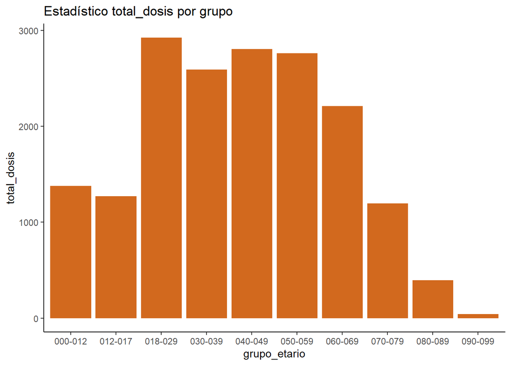

```r
grafico_estandar(ls_ed_df, "grupo_etario", "total_dosis")
```

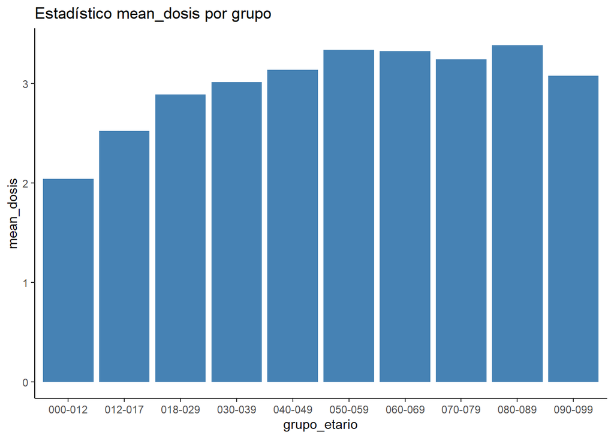

```r
grafico_estandar(ls_ed_df, "grupo_etario", "mean_dosis")
```

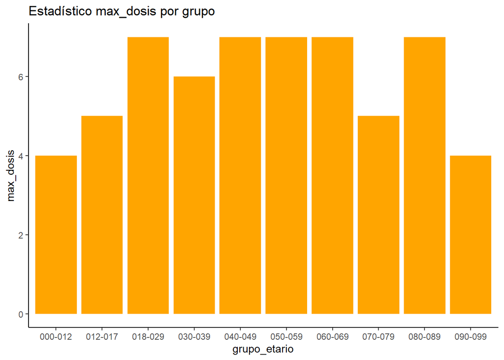

```r
grafico_estandar(ls_ed_df, "grupo_etario", "max_dosis")
```

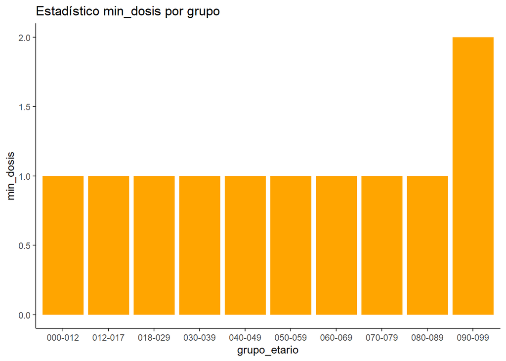

```r
grafico_estandar(ls_ed_df, "grupo_etario", "min_dosis")
```

```r
ls_ed_df$grupo_etario
```

```
## # A tibble: 10 × 7
##    grupo_etario min_dosis mean_dosis max_dosis total_dosis poblacion
##    <chr>            <dbl>      <dbl>     <dbl>       <dbl>     <int>
##  1 000-012              1       2.04         4        1380       676
##  2 012-017              1       2.52         5        1270       503
##  3 018-029              1       2.89         7        2927      1013
##  4 030-039              1       3.01         6        2591       860
##  5 040-049              1       3.14         7        2807       894
##  6 050-059              1       3.34         7        2763       827
##  7 060-069              1       3.33         7        2212       665
##  8 070-079              1       3.24         5        1197       369
##  9 080-089              1       3.39         7         393       116
## 10 090-099              2       3.08         4          40        13
## # ℹ 1 more variable: participacion <dbl>
```